# Отчёт по лабораторной работе №9

Командная оболочка Midnight Commander

Автор

принадлежность

Терентеевская Светлана Александровна, Student

Российский университет дружбы народов

Дата публикации

2026-04-03

# Информация

## Докладчик

- Терентеевская Светлана Александровна
- Группа НКАбд-05-25, студент бакалавра
- Российский университет дружбы народов им. П. Лумумбы
- 1032253498@rudn.ru
- https://github.com/SvetlanaTerenteevskaya

# Вводная часть

## Цель работы

Освоить основные возможностей командной оболочки Midnight Commander. Приобрести навыки практической работы по просмотру каталогов и файлов; манипуляций с ними.

## Задание

- Освоить интерфейс и базовые операции Midnight Commander.
- Научиться использовать основные меню mc.
- Овладеть встроенным редактором mc.

## Теоретическое введение

### Midnight Commander (mc)

Псевдографическая файловая оболочка для Linux/Unix. Запуск:

mc

### Основные возможности Midnight Commander (mc)

| Действие | Клавиши |
| --- | --- |
| Просмотр файла | `F3` |
| Редактирование файла | `F4` |
| Копирование | `F5` |
| Перемещение | `F6` |
| Создание каталога | `F7` |
| Удаление | `F8` |
| Выход из mc | `F10` |

### Управление панелями

| Действие | Клавиши |
| --- | --- |
| Переставить панели местами | `Ctrl + u` |
| Временно отключить панели | `Ctrl + o` |
| Сравнить содержимое каталогов | `Ctrl + x` → `d` |

### Режимы отображения панели

| Режим | Назначение |
| --- | --- |
| Стандартный | Список файлов каталога |
| Информация | Сведения о файле и файловой системе |
| Дерево | Древовидная структура каталогов |

### Меню (вызов — `F9`)

| Меню | Назначение |
| --- | --- |
| Левая панель | Настройка левой панели |
| Правая панель | Настройка правой панели |
| Файл | Операции с файлами |
| Команда | Поиск, история команд, быстрые переходы |
| Настройки | Внешний вид и поведение mc |

### Встроенный редактор (вызов — `F4`)

[output not shown]

# Выполнение лабораторной работы

## Задание по mc

1-2. Я изучила информацию о mc, вызвав в командной строке man mc и запустила из командной строки mc, изучила его структуру и меню (рис. 1).

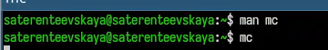

Рисунок 1: Изучение и запуск mc

3. Выполнила несколько операций в mc, используя управляющие клавиши (операции с панелями; выделение/отмена выделения файлов, копирование/перемещение файлов, получение информации о размере и правах доступа на файлы и/или каталоги и т.п.) (рис. 2, рис. 3, рис. 4)

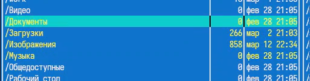

Рисунок 2: Выделение файлов

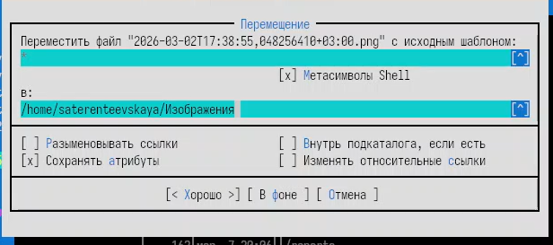

Рисунок 3: Перемещение файлов

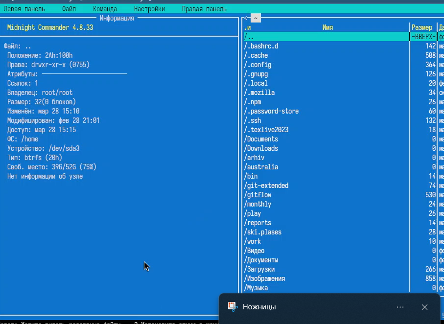

Рисунок 4: Информация про файл

4. Выполнила основные команды меню левой (или правой) панели. Оценила степень подробности вывода информации о файлах (рис. 5, рис. 6, рис. 7, рис. 8, рис. 9).

[figure not shown]

[figure not shown]

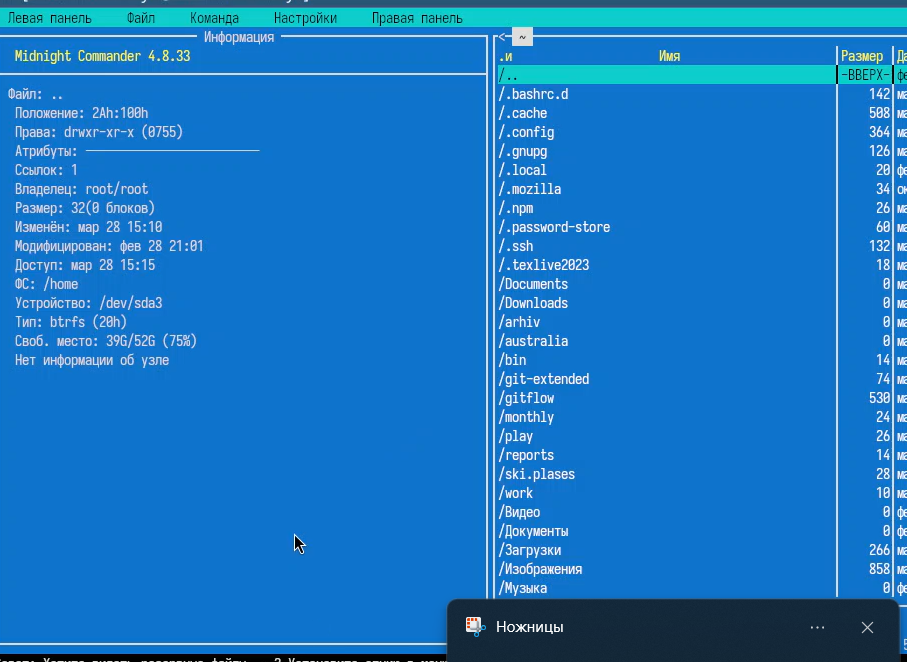

Рисунок 7: Информация про файл

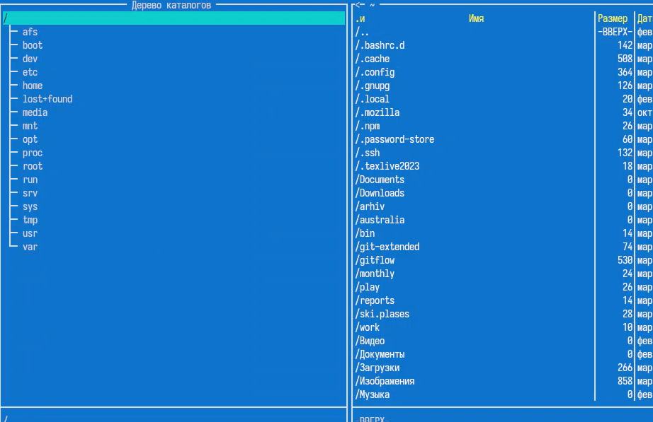

Рисунок 8: Просмотр дерева каталогоа

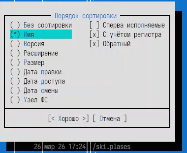

Рисунок 9: Порядок сортировки

5. Используя возможности подменю Файл , я выполнила:

– просмотр содержимого текстового файла (рис. 10);

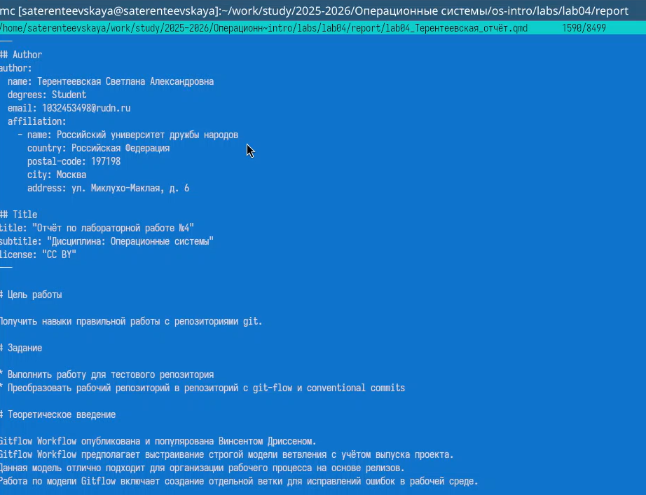

Рисунок 10: Просмтор содержимого

– редактирование содержимого текстового файла (без сохранения результатов редактирования) (рис. 11);

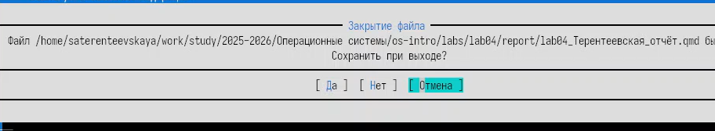

Рисунок 11: Закрытие без сохранения

– создание каталога (рис. 12);

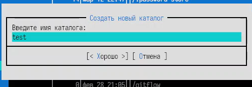

Рисунок 12: Создание каталога

– копирование в файлов в созданный каталог (рис. 13).

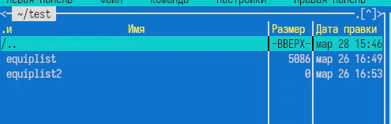

Рисунок 13: Копирование в каталог

6. С помощью соответствующих средств подменю Команда осуществила:

– поиск в файловой системе файла с заданными условиями (файл с расширением qmd и содержимым author) (рис. 14);

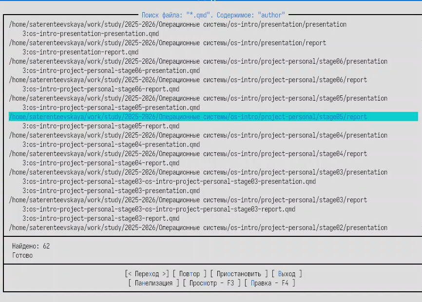

Рисунок 14: Поиск с условиями

– выбор и повторение одной из предыдущих команд (рис. 15);

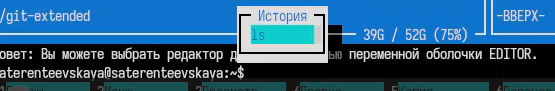

Рисунок 15: История команд

– переход в домашний каталог (рис. 16);

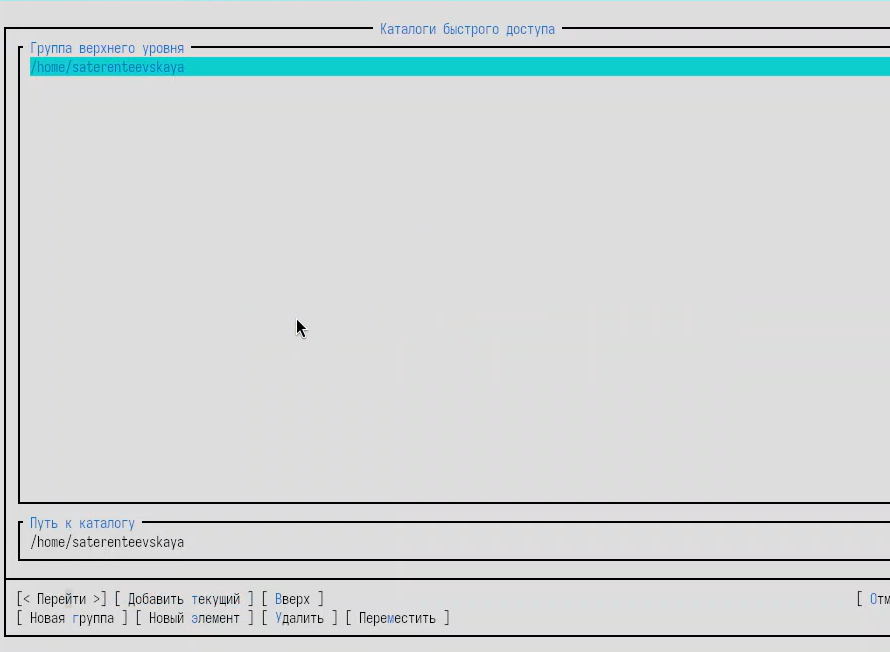

Рисунок 16: Переход в домашний каталог

– анализ файла меню и файла расширений (рис. 17, рис. 18).

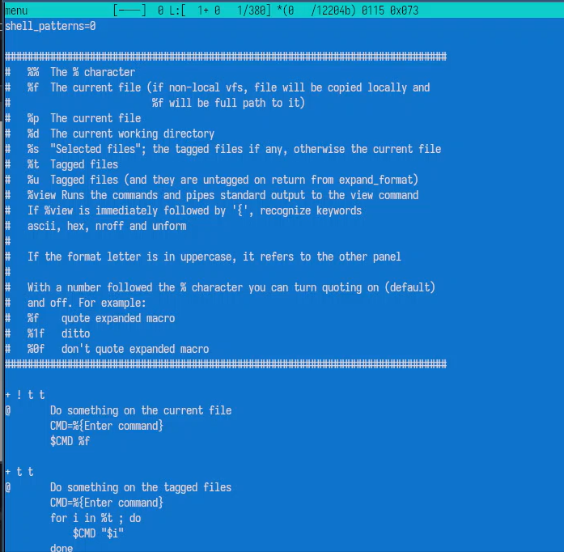

Рисунок 17: Файл меню

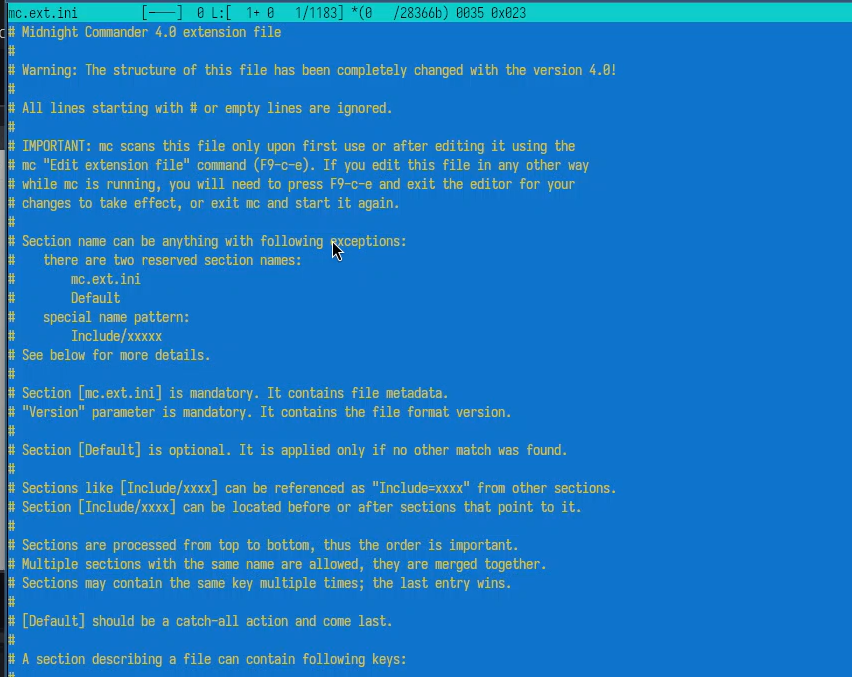

Рисунок 18: Файл расширений

7. Вызвала подменю Настройки . Освоила операции, определяющие структуру экрана mc (рис. 19, рис. 20).

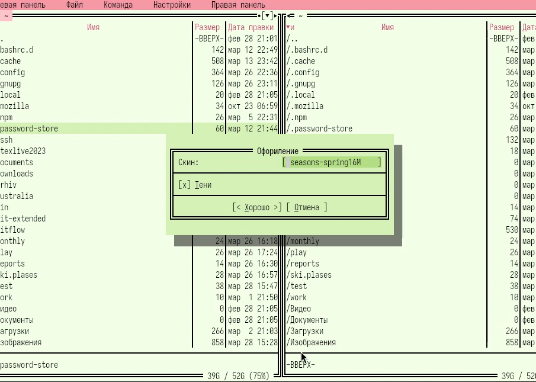

Рисунок 19: Оформление

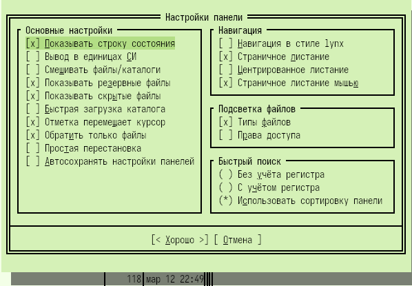

Рисунок 20: Настройки панели

## Задание по встроенному редактору mc

1-3. Я создала текстовой файл text.txt, открыла этот файл с помощью встроенного в mc редактора и вставила в открытый файл небольшой фрагмент текста, скопированный из другого файла (рис. 21).

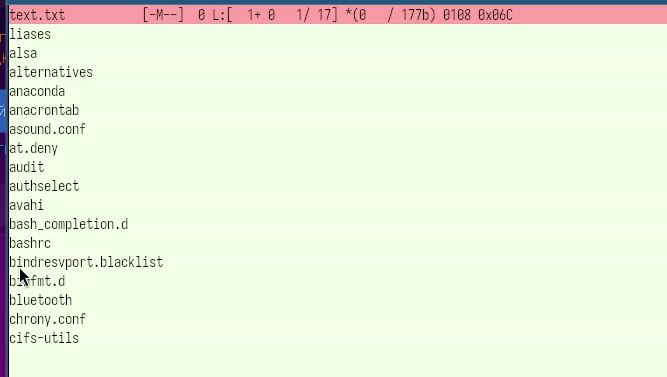

Рисунок 21: Файл text.txt

4. Проделала с текстом следующие манипуляции, используя горячие клавиши:

4.1. Удалила строки текста (рис. 22).

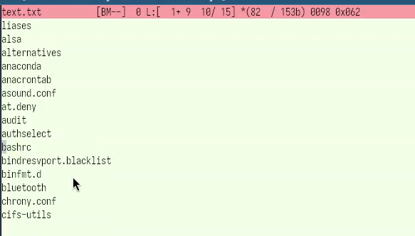

Рисунок 22: Удаление строк

4.2. Выделила фрагмент текста и скопировала его на новую строку (рис. 23).

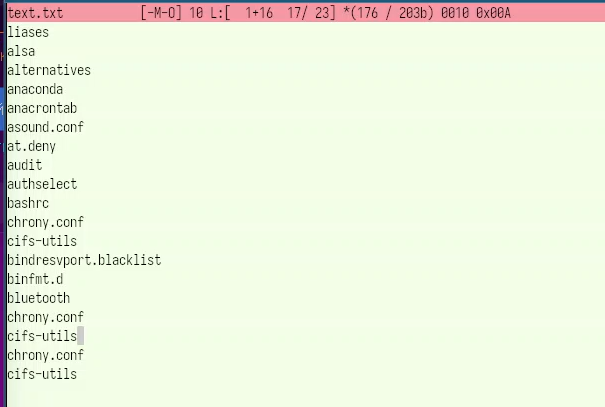

Рисунок 23: Копирование на новую строку

4.3. Выделила фрагмент текста и перенесила его на новую строку (рис. 24).

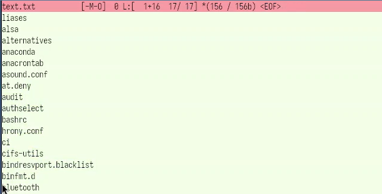

Рисунок 24: Перенос на новую строку

4.4. Сохранила файл (рис. 25).

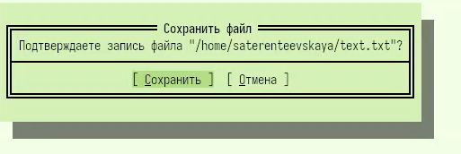

Рисунок 25: Сохранение файла

4.5-4.6. Отменила последнее действие и перейшла в конец файла (нажав комбинацию клавиш), написала некоторый текста, перешла в начало файла (нажав комбинацию клавиш) и написала некоторый текст (рис. 26).

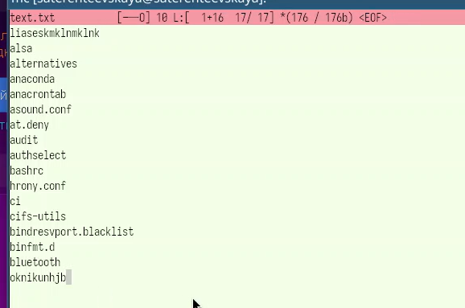

Рисунок 26: Добавление некоторого текста

4.8. Сохранила и закрыла файл (рис. 27).

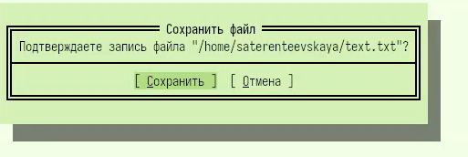

Рисунок 27: Сохранение файла

5. Открыла файл с исходным текстом на некотором языке программирования (С) (рис. 28).

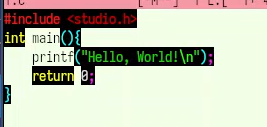

Рисунок 28: Файл на языке программирования

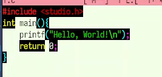

Рисунок 30: С подсветкой

# Выводы

В ходе выполнения лабораторной работы я освоила основные возможности командной оболочки Midnight Commander. Приобрела навыки практической работы по просмотру каталогов и файлов; манипуляций с ними.

# Список литературы

[Методичка к лабораторной работе №9](https://esystem.rudn.ru/pluginfile.php/3097022/mod_resource/content/5/007-lab_mc.pdf)

[ТУИС](https://esystem.rudn.ru)